# Arbol de regresión con datos Advertising

Luis Alberto Jiménez Soto

2022-10-04

# 1 Objetivo

Crear y evaluar un modelo de árbol de regresión para predecir las ventas con datos simulados de una empresa dependiendo de las inversiones realizadas en publicidad.

# 2 Descripción

- Cargar librerías y datos
- Limpiar datos si es necesario
- Explorar datos
- Partir los datos en datos de entrenamiento y datos de validación 70% y 30%
- Crear modelo de árbol de regresión con los datos de entrenamiento
- Hacer Predicciones con datos de validación
- Evaluar predicciones
- Determinar el estadístico *rmse* para evaluar con respecto a otros modelos
- Interpretar el caso

# 3 Fundamento teórico

Los algoritmos de aprendizaje basados en árbol se consideran uno de los mejores y más utilizados métodos de aprendizaje supervisado. Potencian modelos predictivos con alta precisión, estabilidad y facilidad de interpretación.

Los árboles de clasificación y **regresión** son métodos que proporcionan modelos que satisfacen objetivos tanto predictivos como explicativos.

Algunas ventajas son su sencillez y la representación gráfica mediante árboles y, por otro, la definición de reglas de asociación entre variables que incluye expresiones de condición que permiten explicar las predicciones.

Se pueden usar para regresiones con variables dependientes que tienen valores numéricos continuos o para clasificaciones con variables categóricas.

Utilizar un árbol de regresión para crear un modelo explicativo y predictivo para una variable cuantitativa dependiente basada en variables explicativas independientes cuantitativas y cualitativas [@xlstatbyaddinsoft].

Un árbol de regresión consiste en hacer preguntas de tipo $¿x_k < c?$ para cada una de las covariables, de esta forma el espacio de las covariables es divido en hiper-rectángulos (con el resultado de las condicionales) de las observaciones que queden dentro de un hiper-rectángulo tendrán el mismo valor estimado $\hat{y}$ o $Y$ .[@hernández2021]

Por otra parte, bajo el paradigma divide y vencerás, usando árboles de regresión y decisión y correspondientes reglas, el árbol representa el modelo similar a un diagrama de flujo en el que los nodos de decisión, los nodos de hoja y las ramas definen una serie de decisiones que se pueden usar para generar predicciones. Siguiendo las reglas se encuentran predicciones en la hoja final. [@lantz2013].

# 4 Desarrollo

## 4.1 Cargar librerías

```r
library(readr) # Para importar datos
library(dplyr) # Para filtrar
library(knitr) # Para datos tabulares
library(ggplot2) # Para visualizar
library(plotly)
library(caret)  # Para particionar
library(Metrics) # Para determinar rmse
library(rpart) # Para árbol
library(rpart.plot) # Para árbol
```

## 4.2 Cargar datos

```r
datos <- read.csv("https://raw.githubusercontent.com/rpizarrog/Analisis-Inteligente-de-datos/main/datos/Advertising_Web.csv")
```

## 4.3 Explorar datos

La variable dependiente o variable objetivo es *Sales* que deberá estar en función de la inversión que se hace en *TV, Radio, Newspaper* o *Web*.

```r
str(datos)
```

```
## 'data.frame':    200 obs. of  7 variables:
##  $ X.1      : int  1 2 3 4 5 6 7 8 9 10 ...
##  $ X        : int  1 2 3 4 5 6 7 8 9 10 ...
##  $ TV       : num  230.1 44.5 17.2 151.5 180.8 ...
##  $ Radio    : num  37.8 39.3 45.9 41.3 10.8 48.9 32.8 19.6 2.1 2.6 ...
##  $ Newspaper: num  69.2 45.1 69.3 58.5 58.4 75 23.5 11.6 1 21.2 ...
##  $ Web      : num  306.6 302.7 49.5 257.8 195.7 ...
##  $ Sales    : num  22.1 10.4 9.3 18.5 12.9 7.2 11.8 13.2 4.8 10.6 ...
```

```r
summary(datos)
```

```
##       X.1               X                TV             Radio
##  Min.   :  1.00   Min.   :  1.00   Min.   :  0.70   Min.   : 0.000
##  1st Qu.: 50.75   1st Qu.: 50.75   1st Qu.: 74.38   1st Qu.: 9.975
##  Median :100.50   Median :100.50   Median :149.75   Median :22.900
##  Mean   :100.50   Mean   :100.50   Mean   :147.04   Mean   :23.264
##  3rd Qu.:150.25   3rd Qu.:150.25   3rd Qu.:218.82   3rd Qu.:36.525
##  Max.   :200.00   Max.   :200.00   Max.   :296.40   Max.   :49.600
##    Newspaper           Web              Sales
##  Min.   :  0.30   Min.   :  4.308   Min.   : 1.60
##  1st Qu.: 12.75   1st Qu.: 99.049   1st Qu.:10.38
##  Median : 25.75   Median :156.862   Median :12.90
##  Mean   : 30.55   Mean   :159.587   Mean   :14.02
##  3rd Qu.: 45.10   3rd Qu.:212.312   3rd Qu.:17.40
##  Max.   :114.00   Max.   :358.247   Max.   :27.00
```

### 4.3.1 Limpiar datos

Quitar las primeras columnas

```r
datos <- select(datos, TV, Radio, Newspaper, Web, Sales)
```

### 4.3.2 head(datos)

```r
kable(head(datos, 20), caption = "Primeros 20 registros")
```

Primeros 20 registros

| TV | Radio | Newspaper | Web | Sales |
| --- | --- | --- | --- | --- |
| 230.1 | 37.8 | 69.2 | 306.63475 | 22.1 |
| 44.5 | 39.3 | 45.1 | 302.65307 | 10.4 |
| 17.2 | 45.9 | 69.3 | 49.49891 | 9.3 |
| 151.5 | 41.3 | 58.5 | 257.81689 | 18.5 |
| 180.8 | 10.8 | 58.4 | 195.66008 | 12.9 |
| 8.7 | 48.9 | 75.0 | 22.07240 | 7.2 |
| 57.5 | 32.8 | 23.5 | 246.81160 | 11.8 |
| 120.2 | 19.6 | 11.6 | 229.97146 | 13.2 |
| 8.6 | 2.1 | 1.0 | 144.61739 | 4.8 |
| 199.8 | 2.6 | 21.2 | 111.27226 | 10.6 |
| 66.1 | 5.8 | 24.2 | 45.35903 | 8.6 |
| 214.7 | 24.0 | 4.0 | 164.97176 | 17.4 |
| 23.8 | 35.1 | 65.9 | 87.92109 | 9.2 |
| 97.5 | 7.6 | 7.2 | 173.65804 | 9.7 |
| 204.1 | 32.9 | 46.0 | 245.77496 | 19.0 |
| 195.4 | 47.7 | 52.9 | 148.09513 | 22.4 |
| 67.8 | 36.6 | 114.0 | 202.63890 | 12.5 |
| 281.4 | 39.6 | 55.8 | 41.75531 | 24.4 |
| 69.2 | 20.5 | 18.3 | 210.48991 | 11.3 |
| 147.3 | 23.9 | 19.1 | 268.73538 | 14.6 |

### 4.3.3 tail(datos)

```r
kable(tail(datos, 20), caption = "Últimos 20 registros")
```

Últimos 20 registros

|  | TV | Radio | Newspaper | Web | Sales |
| --- | --- | --- | --- | --- | --- |
| 181 | 156.6 | 2.6 | 8.3 | 122.11647 | 10.5 |
| 182 | 218.5 | 5.4 | 27.4 | 162.38749 | 12.2 |
| 183 | 56.2 | 5.7 | 29.7 | 42.19929 | 8.7 |
| 184 | 287.6 | 43.0 | 71.8 | 154.30972 | 26.2 |
| 185 | 253.8 | 21.3 | 30.0 | 181.57905 | 17.6 |
| 186 | 205.0 | 45.1 | 19.6 | 208.69269 | 22.6 |
| 187 | 139.5 | 2.1 | 26.6 | 236.74404 | 10.3 |
| 188 | 191.1 | 28.7 | 18.2 | 239.27571 | 17.3 |
| 189 | 286.0 | 13.9 | 3.7 | 151.99073 | 15.9 |
| 190 | 18.7 | 12.1 | 23.4 | 222.90695 | 6.7 |
| 191 | 39.5 | 41.1 | 5.8 | 219.89058 | 10.8 |
| 192 | 75.5 | 10.8 | 6.0 | 301.48119 | 9.9 |
| 193 | 17.2 | 4.1 | 31.6 | 265.02864 | 5.9 |
| 194 | 166.8 | 42.0 | 3.6 | 192.24621 | 19.6 |
| 195 | 149.7 | 35.6 | 6.0 | 99.57998 | 17.3 |
| 196 | 38.2 | 3.7 | 13.8 | 248.84107 | 7.6 |
| 197 | 94.2 | 4.9 | 8.1 | 118.04186 | 9.7 |
| 198 | 177.0 | 9.3 | 6.4 | 213.27467 | 12.8 |
| 199 | 283.6 | 42.0 | 66.2 | 237.49806 | 25.5 |
| 200 | 232.1 | 8.6 | 8.7 | 151.99073 | 13.4 |

## 4.4 Datos de entrenamiento y validación

### 4.4.1 Datos de entrenamiento

```r
n <- nrow(datos)
# Modificar la semilla estableciendo como parámetro los útimos cuatro dígitos de su no de control.
# Ej. set.seed(0732), o set.seed(1023)
# set.seed(2022) //Para esta calse se decidio usar la semilla propuesta conformada por los utlimos cuatro numeros del numero de control escolar 1271
set.seed(1271)
```

De manera aleatoria se construyen los datos de entrenamiento y los datos de validación.

En la variable *entrena* se generan los registros que van a ser los datos de entrenamiento, de tal forma que los datos de validación serán los que no sena de entrenamiento [-*entrena*].

```r
entrena <- createDataPartition(y = datos$Sales, p = 0.70, list = FALSE, times = 1)
# Datos entrenamiento
datos.entrenamiento <- datos[entrena, ]  # [renglones, columna]
# Datos validación
datos.validacion <- datos[-entrena, ]
```

#### 4.4.1.1 head()

```r
kable(head(datos.entrenamiento, 20), caption = "Datos de Entrenamiento. Primeros 20 registros")
```

Datos de Entrenamiento. Primeros 20 registros

|  | TV | Radio | Newspaper | Web | Sales |
| --- | --- | --- | --- | --- | --- |
| 2 | 44.5 | 39.3 | 45.1 | 302.65307 | 10.4 |
| 3 | 17.2 | 45.9 | 69.3 | 49.49891 | 9.3 |
| 4 | 151.5 | 41.3 | 58.5 | 257.81689 | 18.5 |
| 5 | 180.8 | 10.8 | 58.4 | 195.66008 | 12.9 |
| 6 | 8.7 | 48.9 | 75.0 | 22.07240 | 7.2 |
| 8 | 120.2 | 19.6 | 11.6 | 229.97146 | 13.2 |
| 9 | 8.6 | 2.1 | 1.0 | 144.61739 | 4.8 |
| 11 | 66.1 | 5.8 | 24.2 | 45.35903 | 8.6 |
| 12 | 214.7 | 24.0 | 4.0 | 164.97176 | 17.4 |
| 13 | 23.8 | 35.1 | 65.9 | 87.92109 | 9.2 |
| 14 | 97.5 | 7.6 | 7.2 | 173.65804 | 9.7 |
| 15 | 204.1 | 32.9 | 46.0 | 245.77496 | 19.0 |
| 18 | 281.4 | 39.6 | 55.8 | 41.75531 | 24.4 |
| 21 | 218.4 | 27.7 | 53.4 | 59.96055 | 18.0 |
| 22 | 237.4 | 5.1 | 23.5 | 296.95207 | 12.5 |
| 24 | 228.3 | 16.9 | 26.2 | 51.17007 | 15.5 |
| 25 | 62.3 | 12.6 | 18.3 | 256.96524 | 9.7 |
| 26 | 262.9 | 3.5 | 19.5 | 160.56286 | 12.0 |
| 27 | 142.9 | 29.3 | 12.6 | 275.51248 | 15.0 |
| 28 | 240.1 | 16.7 | 22.9 | 228.15744 | 15.9 |

#### 4.4.1.2 tail()

```r
kable(tail(datos.entrenamiento, 20), caption = "Datos de entrenamiento ültimos 20 registros")
```

Datos de entrenamiento ültimos 20 registros

|  | TV | Radio | Newspaper | Web | Sales |
| --- | --- | --- | --- | --- | --- |
| 174 | 168.4 | 7.1 | 12.8 | 218.18083 | 11.7 |
| 175 | 222.4 | 3.4 | 13.1 | 144.52566 | 11.5 |
| 178 | 170.2 | 7.8 | 35.2 | 104.91734 | 11.7 |
| 179 | 276.7 | 2.3 | 23.7 | 137.32377 | 11.8 |
| 180 | 165.6 | 10.0 | 17.6 | 151.99073 | 12.6 |
| 181 | 156.6 | 2.6 | 8.3 | 122.11647 | 10.5 |
| 182 | 218.5 | 5.4 | 27.4 | 162.38749 | 12.2 |
| 183 | 56.2 | 5.7 | 29.7 | 42.19929 | 8.7 |
| 184 | 287.6 | 43.0 | 71.8 | 154.30972 | 26.2 |
| 186 | 205.0 | 45.1 | 19.6 | 208.69269 | 22.6 |
| 187 | 139.5 | 2.1 | 26.6 | 236.74404 | 10.3 |
| 188 | 191.1 | 28.7 | 18.2 | 239.27571 | 17.3 |
| 189 | 286.0 | 13.9 | 3.7 | 151.99073 | 15.9 |
| 190 | 18.7 | 12.1 | 23.4 | 222.90695 | 6.7 |
| 191 | 39.5 | 41.1 | 5.8 | 219.89058 | 10.8 |
| 192 | 75.5 | 10.8 | 6.0 | 301.48119 | 9.9 |
| 194 | 166.8 | 42.0 | 3.6 | 192.24621 | 19.6 |
| 197 | 94.2 | 4.9 | 8.1 | 118.04186 | 9.7 |
| 199 | 283.6 | 42.0 | 66.2 | 237.49806 | 25.5 |
| 200 | 232.1 | 8.6 | 8.7 | 151.99073 | 13.4 |

### 4.4.2 Datos de validación

Los datos de validación deben ser diferentes a los datos den entrenamiento.

#### 4.4.2.1 head()

```r
kable(head(datos.validacion, 20), caption = "Datos de Validación Primeros 20 registros")
```

Datos de Validación Primeros 20 registros

|  | TV | Radio | Newspaper | Web | Sales |
| --- | --- | --- | --- | --- | --- |
| 1 | 230.1 | 37.8 | 69.2 | 306.63475 | 22.1 |
| 7 | 57.5 | 32.8 | 23.5 | 246.81160 | 11.8 |
| 10 | 199.8 | 2.6 | 21.2 | 111.27226 | 10.6 |
| 16 | 195.4 | 47.7 | 52.9 | 148.09513 | 22.4 |
| 17 | 67.8 | 36.6 | 114.0 | 202.63890 | 12.5 |
| 19 | 69.2 | 20.5 | 18.3 | 210.48991 | 11.3 |
| 20 | 147.3 | 23.9 | 19.1 | 268.73538 | 14.6 |
| 23 | 13.2 | 15.9 | 49.6 | 219.88278 | 5.6 |
| 37 | 266.9 | 43.8 | 5.0 | 96.31683 | 25.4 |
| 39 | 43.1 | 26.7 | 35.1 | 122.75359 | 10.1 |
| 42 | 177.0 | 33.4 | 38.7 | 147.85932 | 17.1 |
| 43 | 293.6 | 27.7 | 1.8 | 174.71682 | 20.7 |
| 46 | 175.1 | 22.5 | 31.5 | 62.80926 | 14.9 |
| 49 | 227.2 | 15.8 | 49.9 | 75.26918 | 14.8 |
| 52 | 100.4 | 9.6 | 3.6 | 41.33526 | 10.7 |
| 56 | 198.9 | 49.4 | 60.0 | 204.41893 | 23.7 |
| 57 | 7.3 | 28.1 | 41.4 | 121.32853 | 5.5 |
| 66 | 69.0 | 9.3 | 0.9 | 205.99349 | 9.3 |
| 68 | 139.3 | 14.5 | 10.2 | 207.66199 | 13.4 |
| 70 | 216.8 | 43.9 | 27.2 | 149.39610 | 22.3 |

#### 4.4.2.2 tail()

```r
kable(tail(datos.validacion, 20), caption = "Datos de validació últimos 20 registros")
```

Datos de validació últimos 20 registros

|  | TV | Radio | Newspaper | Web | Sales |
| --- | --- | --- | --- | --- | --- |
| 132 | 265.2 | 2.9 | 43.0 | 172.156659 | 12.7 |
| 137 | 25.6 | 39.0 | 9.3 | 77.230797 | 9.5 |
| 138 | 273.7 | 28.9 | 59.7 | 288.260611 | 20.8 |
| 139 | 43.0 | 25.9 | 20.5 | 181.368741 | 9.6 |
| 143 | 220.5 | 33.2 | 37.9 | 6.007436 | 20.1 |
| 148 | 243.2 | 49.0 | 44.3 | 151.990733 | 25.4 |
| 158 | 149.8 | 1.3 | 24.3 | 145.803211 | 10.1 |
| 161 | 172.5 | 18.1 | 30.7 | 207.496801 | 14.4 |
| 164 | 163.5 | 36.8 | 7.4 | 82.228794 | 18.0 |
| 167 | 17.9 | 37.6 | 21.6 | 99.936953 | 8.0 |
| 168 | 206.8 | 5.2 | 19.4 | 115.371957 | 12.2 |
| 169 | 215.4 | 23.6 | 57.6 | 203.431267 | 17.1 |
| 172 | 164.5 | 20.9 | 47.4 | 96.180391 | 14.5 |
| 176 | 276.9 | 48.9 | 41.8 | 151.990733 | 27.0 |
| 177 | 248.4 | 30.2 | 20.3 | 163.852044 | 20.2 |
| 185 | 253.8 | 21.3 | 30.0 | 181.579051 | 17.6 |
| 193 | 17.2 | 4.1 | 31.6 | 265.028644 | 5.9 |
| 195 | 149.7 | 35.6 | 6.0 | 99.579981 | 17.3 |
| 196 | 38.2 | 3.7 | 13.8 | 248.841073 | 7.6 |
| 198 | 177.0 | 9.3 | 6.4 | 213.274671 | 12.8 |

## 4.5 Construir el modelo

Se construye el modelo con la función *rpart*

```r
modelo_ar <- rpart(data = datos.entrenamiento,formula = Sales ~ TV + Radio + Newspaper )
modelo_ar
```

```
## n= 142
##
## node), split, n, deviance, yval
##       * denotes terminal node
##
##  1) root 142 3618.954000 14.052110
##    2) TV< 122.05 57  403.810500  9.826316
##      4) TV< 29.5 18   43.300000  7.033333 *
##      5) TV>=29.5 39  155.290800 11.115380
##       10) Radio< 13.3 16   11.870000  9.525000 *
##       11) Radio>=13.3 23   74.799130 12.221740
##         22) TV< 74.05 9    2.768889 10.611110 *
##         23) TV>=74.05 14   33.674290 13.257140 *
##    3) TV>=122.05 85 1514.703000 16.885880
##      6) Radio< 26.95 46  188.846100 13.682610
##       12) Radio< 10.05 22   17.255000 11.950000 *
##       13) Radio>=10.05 24   45.009580 15.270830 *
##      7) Radio>=26.95 39  297.129700 20.664100
##       14) Radio< 35.85 17   47.949410 18.594120 *
##       15) Radio>=35.85 22  120.050900 22.263640
##         30) TV< 194.95 7    7.917143 19.457140 *
##         31) TV>=194.95 15   31.269330 23.573330 *
```

### 4.5.1 resumen del modelo

```r
summary(modelo_ar)
```

```
## Call:
## rpart(formula = Sales ~ TV + Radio + Newspaper, data = datos.entrenamiento)
##   n= 142
##
##           CP nsplit  rel error    xerror       xstd
## 1 0.46987074      0 1.00000000 1.0246165 0.10439855
## 2 0.28426090      1 0.53012926 0.6289700 0.06416534
## 3 0.05670692      2 0.24586836 0.3222286 0.04361484
## 4 0.03568142      3 0.18916143 0.2315346 0.02854290
## 5 0.03497737      4 0.15348002 0.2399648 0.02855040
## 6 0.02234470      5 0.11850265 0.2015114 0.02706534
## 7 0.01896173      6 0.09615795 0.1709032 0.02167725
## 8 0.01059863      7 0.07719622 0.1581256 0.02147722
## 9 0.01000000      8 0.06659759 0.1361288 0.01717059
##
## Variable importance
##        TV     Radio Newspaper
##        51        36        14
##
## Node number 1: 142 observations,    complexity param=0.4698707
##   mean=14.05211, MSE=25.48559
##   left son=2 (57 obs) right son=3 (85 obs)
##   Primary splits:
##       TV        < 122.05 to the left,  improve=0.4698707, (0 missing)
##       Radio     < 27.35  to the left,  improve=0.2970867, (0 missing)
##       Newspaper < 50.9   to the left,  improve=0.0976701, (0 missing)
##   Surrogate splits:
##       Radio     < 1.75   to the left,  agree=0.634, adj=0.088, (0 split)
##       Newspaper < 2.3    to the left,  agree=0.606, adj=0.018, (0 split)
##
## Node number 2: 57 observations,    complexity param=0.05670692
##   mean=9.826316, MSE=7.084395
##   left son=4 (18 obs) right son=5 (39 obs)
##   Primary splits:
##       TV        < 29.5   to the left,  improve=0.5082080, (0 missing)
##       Radio     < 39.8   to the left,  improve=0.1393039, (0 missing)
##       Newspaper < 30.85  to the left,  improve=0.1128974, (0 missing)
##   Surrogate splits:
##       Newspaper < 65.75  to the right, agree=0.737, adj=0.167, (0 split)
##
```

[output cut: 75 more lines]

```
##       Radio     < 41.4   to the left,  improve=0.03766382, (0 missing)
##   Surrogate splits:
##       Newspaper < 11.05  to the left,  agree=0.727, adj=0.143, (0 split)
##
## Node number 22: 9 observations
##   mean=10.61111, MSE=0.3076543
##
## Node number 23: 14 observations
##   mean=13.25714, MSE=2.405306
##
## Node number 30: 7 observations
##   mean=19.45714, MSE=1.13102
##
## Node number 31: 15 observations
##   mean=23.57333, MSE=2.084622
```

### 4.5.2 Representar visualmente el árbol de regresión

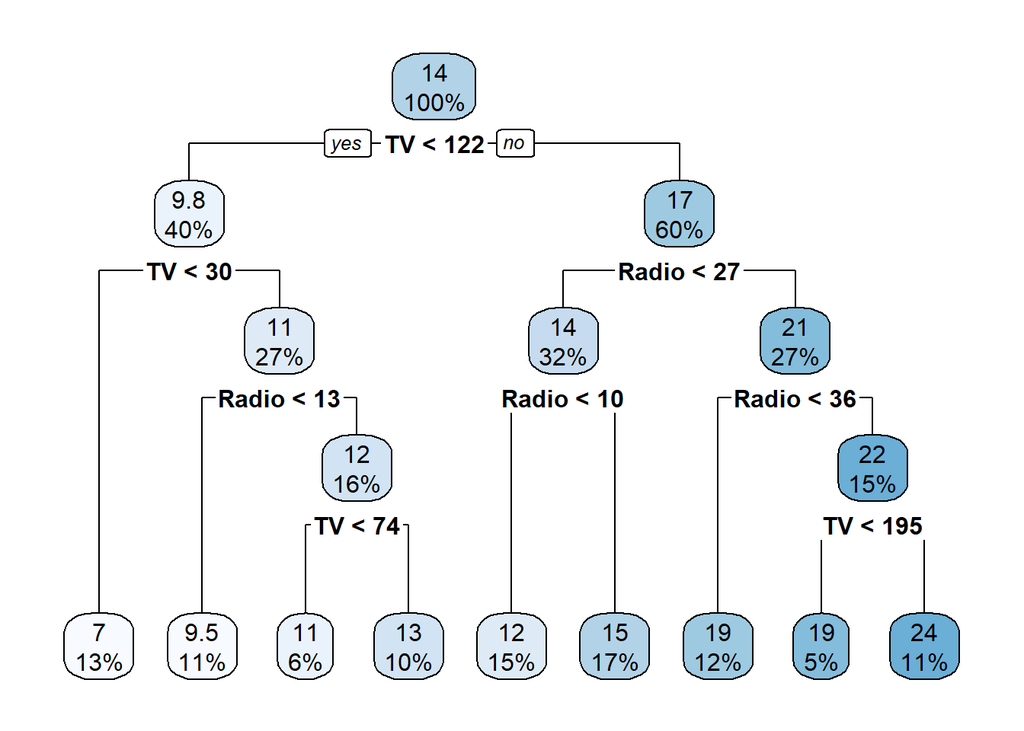

```r
rpart.plot(modelo_ar)
```